# Building a new model to assess HPV16 lineage

## Validation

The 80% of the samples (n = 520) were used to train and test the model, and the remaining 20% (n = 128) has been used to check the sensitivity and specificity of the models.

```r
#The model only include the known nucleotides per snp found in the reference dataset (GWAS), however, some times is possible that a new mutation is present in one of those SNPs. This function changes random mutations per one "n".
Modifications <- NULL
if (length(grep("snp", as.character(evaluate("predict(fit.rf, validation)")[[2]]))) == 0){
  Modifications <- "No modifications were applied to the dataset"
}else{
    while (grep("snp", as.character(evaluate("predict(fit.rf, validation)")[[2]])) >= 1) {
      message <-  as.character(evaluate("predict(fit.rf, validation)")[[2]])
      snp <- sub(".*factor ", "", message)
      snp <- sub("\\ has.*", "", snp)
      nt <- sub(".*levels ", "", message)
      nt <- substr(nt, 1, 1)
      ID <- rownames(validation)[grep(nt, validation[, snp])]
      # show(ID)
      if (length(ID) == 1){
        Modifications <- rbind(Modifications, c(snp, nt, ID))
        levels(validation[,snp]) <- c(levels(validation[,snp]),"n")
        validation[ID, snp] <- "n"
      }else{
        for (i in 1:length(ID)){
          Modifications <- rbind(Modifications, c(snp, nt, ID[i]))
          levels(validation[,snp]) <- c(levels(validation[,snp]),"n")
          validation[ID[i], snp] <- "n"
        }
      }
    }
}

if (is.character(Modifications)== T){ show(Modifications)
}else{ Modifications <- as.data.frame(Modifications); colnames(Modifications) <- c("SNP", "nt", "ID")
  show(Modifications)}
```

```
## [1] "No modifications were applied to the dataset"
```

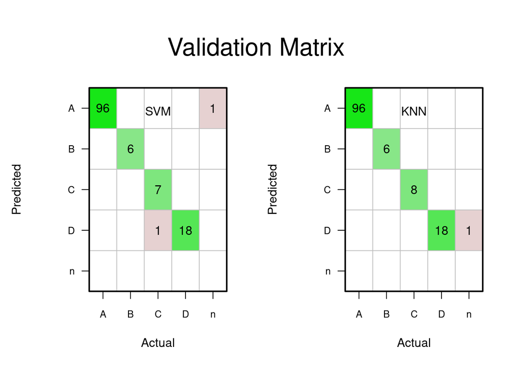

```r
### VALIDATE THE MODEL WITH THE TRAINING TEST-DATA
# dataset

n_sample <- rep("n", ncol(validation))
validation <- as.data.frame(rbind(as.matrix(validation), n_sample))

## 1) Prediction and validation with SVM and KNN
set.seed(ss)
predictions.svm <- predict(fit.svm, validation[,1:(ncol(validation)-1)])
set.seed(ss)
predictions.knn <- predict(fit.knn, validation[,1:(ncol(validation)-1)])

par(mfrow=c(1,2),oma = c(0, 0, 4, 0))
plot.cm(predictions.svm, validation$Lineage, rescales = F)
mtext("SVM", outer = F, cex = 1)
plot.cm(predictions.knn, validation$Lineage, rescales = F)
mtext("KNN", outer = F, cex = 1)
mtext("Validation Matrix", outer = T, cex = 2)
```

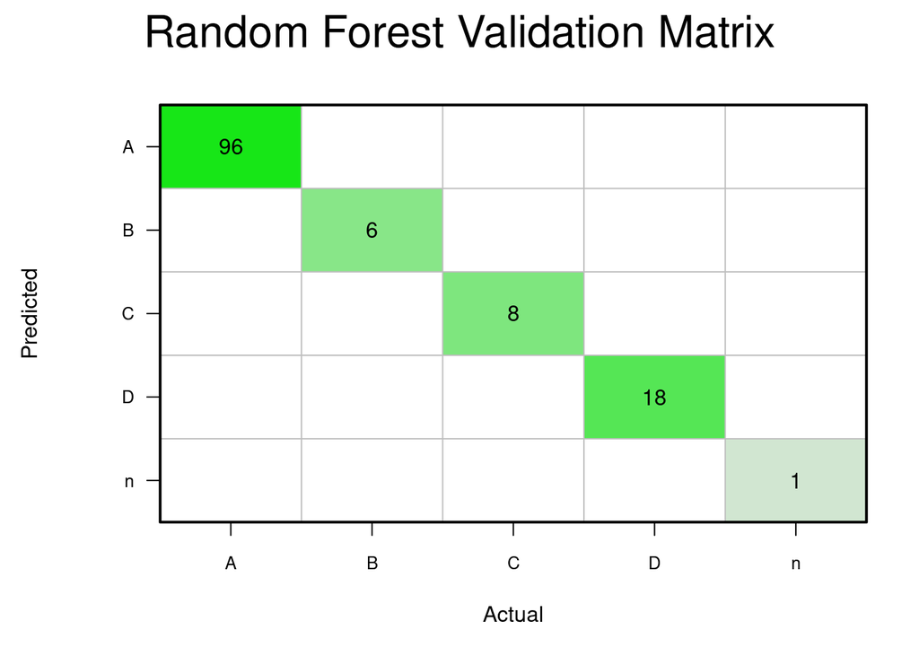

```r
## 2) Prediction and validation with RF
set.seed(ss)
predictions.rf <- predict(fit.rf, validation[,1:(ncol(validation)-1)])

par(mfrow=c(1,1),oma = c(0, 0, 2, 0))
plot.cm(predictions.rf, validation$Lineage, rescales = F)
mtext("Random Forest Validation Matrix", outer = T, cex = 2)
```

```r
save(fit.rf, file = paste(wd_results, "HPV16_Lineage_MODEL_rf.Rdata", sep = ""))
```

KNN, SVM and RF based models showed similar accuracy and kappa values, and although SVM and KNN where placed in a top positions, we opt to chose Random Forest, since it is the unique model that could assess correctly all the samples, showing a perfect validation matrix.